# Speech Recognizer

Made by SeanvonB | [Source](https://github.com/SeanvonB/speech-recognizer)

This was my final for Udacity's [Natural Language Processing Nanodegree](https://www.udacity.com/course/natural-language-processing-nanodegree--nd892), which I completed in late 2020. It's really a summative project for all of my School of AI Nanodegrees: [AI Programming](https://www.udacity.com/course/ai-programming-python-nanodegree--nd089) and [Computer Vision](https://www.udacity.com/course/computer-vision-nanodegree--nd891) included; because it relies heavily on the knowledge from all three courses.

In data science terms, I should actually call this an Automatic Speech Recognition (ASR) pipeline. An ASR pipeline recieves spoken audio as input and returns a text transcript of the speech as output, so you'll often find this at the heart of speech recognition or dictation software. The end result should look something like this:

[figure not shown]

I'll explain the process across the following three sections:

1. Preprocessing
2. Models
3. Prediction

Let's get started!

# 1.0 Preprocessing

As always, I begin by examining the dataset. For this project, Udacity provided us with the [LibriSpeech Corpus](http://www.danielpovey.com/files/2015_icassp_librispeech.pdf), which is about 1,000 hours of English speech samples compiled from public domain audio books. The full corpus can be found [here](http://www.openslr.org/12/); however, for this project, Udacity selected a small subset to help reduce the training burden.

The following loads the dataset, which returns these variables:

> - `vis_text` - transcribed text (label) for the training example.
> - `vis_raw_audio` - raw audio waveform for the training example.
> - `vis_mfcc_feature` - mel-frequency cepstral coefficients (MFCCs) for the training example.
> - `vis_spectrogram_feature` - spectrogram for the training example.
> - `vis_audio_path` - the file path to the training example.

```python
  from data_generator import vis_train_features

  # Extract label and audio features for single training sample
  vis_text, vis_raw_audio, vis_mfcc_feature, vis_spectrogram_feature, vis_audio_path = vis_train_features()
```

```
There are 2023 total training examples.
```

## 1.1 Sample the Data

Next, the following will import the tools necessary for visualizing and playing audio samples. The embedded IPython audio player should allow you to listen to the first sample from the dataset:

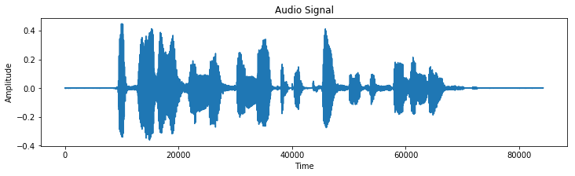

**Shape of Audio Signal** : (84231,)

**Transcript** : her father is a most remarkable person to say the least

[interactive chart not shown]

```python
  from IPython.display import Markdown, display
  from data_generator import vis_train_features, plot_raw_audio
  from IPython.display import Audio
  %matplotlib inline

  # Plot audio signal
  plot_raw_audio(vis_raw_audio)

  # Print length of audio signal
  display(Markdown('**Shape of Audio Signal** : ' + str(vis_raw_audio.shape)))

  # Print corresponding transcript
  display(Markdown('**Transcript** : ' + str(vis_text)))

  # Play audio file
  Audio(vis_audio_path)
```

## 1.2 Choosing Feature Representation

The above sample isn't yet useful to me, because computers can't **hear** – at least, not readily. I've read about some [deep learning architectures that can read raw audio data](https://pdfs.semanticscholar.org/a566/cd4a8623d661a4931814d9dffc72ecbf63c4.pdf), but they're a different beast. However, from projects like my [Facial Keypoint Detector](https://seanvonb.github.io/facial-keypoint-detector/) and [Image Captioner](https://seanvonb.github.io/image-captioner/), I've learned that computers can **see** pretty well. Images are just matrices, so I know the first step to preprocessing this data could simply be to make the audio samples just as matrix-y as possible.

Udacity provided two suggestions:

- [Spectrograms](https://en.wikipedia.org/wiki/Spectrogram)
- [Mel-Frequency Cepstral Coefficients (MFCCs)](https://en.wikipedia.org/wiki/Mel-frequency_cepstrum)

So, let's look at both...

## 1.3 Spectrograms

You know 'em, you love 'em, and you didn't know how to calculate them until you borrowed the calculation from [this repository](https://github.com/baidu-research/ba-dls-deepspeech) for `utils.py`.

Here's an example of one:

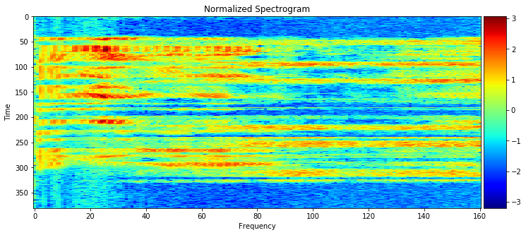

**Shape of Spectrogram** : (381, 161)

```python
  from data_generator import plot_spectrogram_feature

  # Plot normalized spectrogram
  plot_spectrogram_feature(vis_spectrogram_feature)

  # Print spectrogram shape
  display(Markdown('**Shape of Spectrogram** : ' + str(vis_spectrogram_feature.shape)))
```

## 1.4 Mel-Frequency Cepstral Coefficients (MFCCs)

This time, the calculation was boosted from [this repository](https://github.com/jameslyons/python_speech_features) for `utils.py`.

As I'll show in the example below, MFCCs look like simplified versions of spectrograms. Their calculation involves some "*linear cosine transform of a log power spectrum*" stuff, but the [**Mel**](https://en.wikipedia.org/wiki/Mel_scale) part caught my attention. The **Mel scale** is a scale of pitches that human listeners hear as being equidistant from each other, sort of like a scientific [solfège](https://en.wikipedia.org/wiki/Solf%C3%A8ge). So, while they *are* simplified spectrograms in some respect, they've been simplified to favor human experience. That sounds like a way to help a model hear as we do. An MFCC feature is also much lower-dimensional than a spectrogram feature, which could help a model generalize – interesting!

Here's an example of an MFCC; again, normalized:

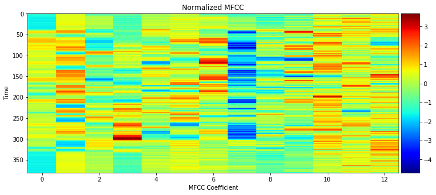

**Shape of MFCC** : (381, 13)

```python
  from data_generator import plot_mfcc_feature

  # Plot normalized MFCC
  plot_mfcc_feature(vis_mfcc_feature)

  # Print MFCC shape
  display(Markdown('**Shape of MFCC** : ' + str(vis_mfcc_feature.shape)))
```

## 2.0 Models

Now that the audio data is preprocessed into a format that a model can recieve, I'll begin playing with some neural network architectures for acoustic modeling. Just like I did with the [Language Translator](https://seanvonb.github.io/language-translator/), I begin simple and add new features after each successful training session.

Here are the steps this stage will take:

1. Simple RNN
2. RNN + TimeDistributed Dense
3. CNN + RNN + TimeDistributed Dense
4. Deep RNN + TimDistributed Dense
5. Bidirectional RNN + TimeDistributed Dense
6. Final Model

And, of course, you know the `final_model` will just be a mash of whatever worked well together.

Let's begin with some workspace utility, provided by Udacity:

```python
  #############################################################
  # RUN THIS CODE CELL IF RESUMING NOTEBOOK AFTER A BREAK #
  #############################################################

  from keras.backend.tensorflow_backend import set_session
  import tensorflow as tf
  config = tf.ConfigProto()
  config.gpu_options.per_process_gpu_memory_fraction = 0.75
  set_session(tf.Session(config=config))

  # Watch for changes in `models.py` and reload automatically
  %load_ext autoreload
  %autoreload 2

  # Import NN architectures for speech recognition
  from models import *
  # Import function for training acoustic model
  from utils import train_model
```

## 2.1 Simple RNN

Again, there isn't anything *simple* about a Recurrent Neural Network, but this one will be the vanilla flavor of the day. Because I'm working with sequential data, all of the models in this notebook will prominantly feature RNNs, and this model will serve was the baseline.

As you can see in this example, this model (and all of the others) will take the acoustic features of the audio sequential per time step:

[figure not shown]

The following example is the same model in what's called the **unrolled** format:

[figure not shown]

The simple RNN is specified in Keras as follows:

```python
  model_0 = simple_rnn_model(input_dim=13) # The `input_dim` = 13 for MFCC features
```

```
_________________________________________________________________
Layer (type)                 Output Shape              Param #
=================================================================
the_input (InputLayer)       (None, None, 13)          0
_________________________________________________________________
rnn (GRU)                    (None, None, 29)          3741
_________________________________________________________________
softmax (Activation)         (None, None, 29)          0
=================================================================
Total params: 3,741
Trainable params: 3,741
Non-trainable params: 0
_________________________________________________________________
None
```

My acoustic models will train with [CTC](http://www.cs.toronto.edu/~graves/icml_2006.pdf) for their loss function. Note: using custom loss functions, like CTC, with Keras required some tinkering in 2020, but I don't know whether this is still true. Udacity helped me implement this criterion as `add_ctc_loss` in `utils.py`.

Finally, training involves a number of **optional** arguments that can fine tune the process:

> - `minibatch_size` - the size of the minibatches that are generated while training the model (default: `20`).
> - `spectrogram` - Boolean value for whether spectrograms (`True`) or MFCCs (`False`) are used for training (default: `True`).
> - `mfcc_dim` - the size of the feature dimension to use when generating MFCC features (default: `13`).
> - `optimizer` - the Keras optimizer used to train the model (default: `SGD`).
> - `epochs` - the number of epochs to use to train the model (default: `20`).
> - `verbose` - controls the verbosity of the training output in the `model.fit_generator` method (default: `1`).
> - `sort_by_duration` - Boolean value dictating whether the training and validation sets are sorted by (increasing) duration before the start of the first epoch (default: `False`).

For all hyperparameters, I choose what I determined to be some commonly accepted "**best practice**" or "**proof of concept**" defaults after some searching on Stack Overflow and Reddit.

I mentioned it before, but you might also notice `input_dim=13` appearing frequently. This indicates that I chose to use MFCCs over spectrograms, the latter of which are `input_dim=161`.

The following cell will train `model_0`:

```python
  train_model(input_to_softmax=model_0,
              pickle_path='model_0.pickle',
              save_model_path='model_0.h5',
              spectrogram=False)
```

```
...
```

## 2.2 RNN + TimeDistributed Dense

The primary change for this model will be the inclusion of [BatchNormalization](https://keras.io/layers/normalization/) via [TimeDistributed](https://keras.io/layers/wrappers/) layer. Generally, *Batch Normalization* refers to a collection of strategies that allow the network to train faster by safely using a higher `learnrate`. In the case of a `TimeDistributed` layer, the network will use this advantage to find more complex relationships in the dataset.

Here is the new model, rolled:

[figure not shown]

But I think the unrolled model illustrates this one much better:

[figure not shown]

The following cells will train `model_1`:

```python
  model_1 = rnn_model(input_dim=13,
                      units=200,
                      activation='relu')
```

```
_________________________________________________________________
Layer (type)                 Output Shape              Param #
=================================================================
the_input (InputLayer)       (None, None, 13)          0
_________________________________________________________________
rnn (GRU)                    (None, None, 200)         128400
_________________________________________________________________
batch_normalization_1 (Batch (None, None, 200)         800
_________________________________________________________________
time_distributed_1 (TimeDist (None, None, 29)          5829
_________________________________________________________________
softmax (Activation)         (None, None, 29)          0
=================================================================
Total params: 135,029
Trainable params: 134,629
Non-trainable params: 400
_________________________________________________________________
None
```

```python
  train_model(input_to_softmax=model_1,
              pickle_path='model_1.pickle',
              save_model_path='model_1.h5',
              spectrogram=False)
```

```
...
```

## 2.3 CNN + RNN + TimeDistributed Dense

Expanding on the previous model, this one includes a 1D [Convolutional Layer](https://keras.io/layers/convolutional/#conv1d), which uses a technique from computer vision to hopefully extract more useful feature maps: sliding a filter over the initial feature representation that enhances important features while muting others.

The resulting model will look like this:

[figure not shown]

The following cells will train `model_2`:

```python
  model_2 = cnn_rnn_model(input_dim=13,
                          filters=200,
                          kernel_size=11,
                          conv_stride=2,
                          conv_border_mode='same',
                          units=200)
```

```
_________________________________________________________________
Layer (type)                 Output Shape              Param #
=================================================================
the_input (InputLayer)       (None, None, 13)          0
_________________________________________________________________
conv1d (Conv1D)              (None, None, 200)         28800
_________________________________________________________________
bn_conv_1d (BatchNormalizati (None, None, 200)         800
_________________________________________________________________
rnn (SimpleRNN)              (None, None, 200)         80200
_________________________________________________________________
batch_normalization_2 (Batch (None, None, 200)         800
_________________________________________________________________
time_distributed_2 (TimeDist (None, None, 29)          5829
_________________________________________________________________
softmax (Activation)         (None, None, 29)          0
=================================================================
Total params: 116,429
Trainable params: 115,629
Non-trainable params: 800
_________________________________________________________________
None
```

```python
  train_model(input_to_softmax=model_2,
              pickle_path='model_2.pickle',
              save_model_path='model_2.h5',
              spectrogram=False)
```

```
...
```

## 2.4 Deeper RNN + TimeDistributed Dense

Until now, the model used a single recurrent layer, but I want to see what happens if I adjust the model to accept any variable number of RNN layers. On one hand, this could simply be overkill that only serves to extend training time; on the other, maybe the depth provided by multiple RNNs will be what cracks this problem – I'll be looking for a strong performance uplift to justify the added layers.

Since I'm worried about training time, I'll temporarily remove the CNN, and the model will look like this:

[figure not shown]

The following cells will train `model_3`:

```python
  model_3 = deep_rnn_model(input_dim=13,
                          units=200,
                          recur_layers=2)
```

```
_________________________________________________________________
Layer (type)                 Output Shape              Param #
=================================================================
the_input (InputLayer)       (None, None, 13)          0
_________________________________________________________________
rnn0 (GRU)                   (None, None, 200)         128400
_________________________________________________________________
batch_normalization_3 (Batch (None, None, 200)         800
_________________________________________________________________
rnn1 (GRU)                   (None, None, 200)         240600
_________________________________________________________________
batch_normalization_4 (Batch (None, None, 200)         800
_________________________________________________________________
time_distributed_3 (TimeDist (None, None, 29)          5829
_________________________________________________________________
softmax (Activation)         (None, None, 29)          0
=================================================================
Total params: 376,429
Trainable params: 375,629
Non-trainable params: 800
_________________________________________________________________
None
```

```python
  train_model(input_to_softmax=model_3,
              pickle_path='model_3.pickle',
              save_model_path='model_3.h5',
              spectrogram=False)
```

```
...
```

## 2.5 Bidirectional RNN + TimeDistributed Dense

Deeper RNNs provide more of the same benefit, but a `Bidirectional` layer provides something new: the ability to see future contexts, which can make a difference when working with language, where quirks like phrasal verbs or split clauses might otherwise confuse the model.

As you can see, this model looks a lot like the last one, but the RNN layers now feed in both directions:

[figure not shown]

The following cells will train `model_4`:

```python
  model_4 = bidirectional_rnn_model(input_dim=13,
                                    units=200)
```

```
_________________________________________________________________
Layer (type)                 Output Shape              Param #
=================================================================
the_input (InputLayer)       (None, None, 13)          0
_________________________________________________________________
bidirectional_1 (Bidirection (None, None, 400)         256800
_________________________________________________________________
time_distributed_4 (TimeDist (None, None, 29)          11629
_________________________________________________________________
softmax (Activation)         (None, None, 29)          0
=================================================================
Total params: 268,429
Trainable params: 268,429
Non-trainable params: 0
_________________________________________________________________
None
```

```python
  train_model(input_to_softmax=model_4,
              pickle_path='model_4.pickle',
              save_model_path='model_4.h5',
              spectrogram=False)
```

```
...
```

## 2.6 Compare the Models

I didn't talk about the performance of each model, because I was waiting for this step. The following cell will plot the change in training and validation loss per epoch for each model, and we can see how each model performed. It may also be possible to see when models begin to overfit or even explode/vanish their gradients. Everything is better with graphs!

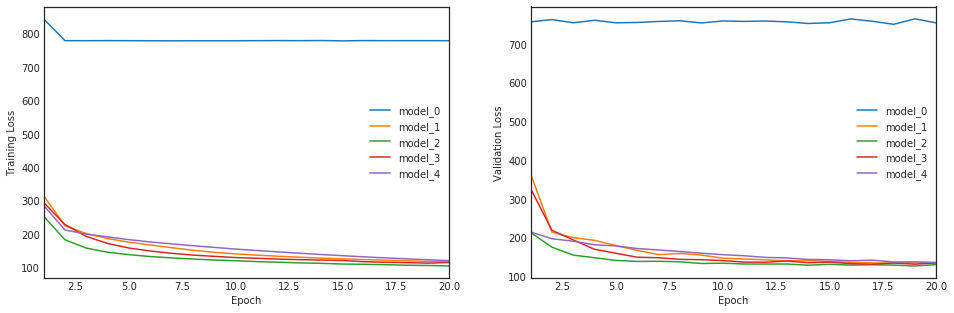

```python
  from glob import glob
  import numpy as np
  import _pickle as pickle
  import seaborn as sns
  import matplotlib.pyplot as plt
  %matplotlib inline
  sns.set_style(style='white')

  # Obtain saved models
  all_pickles = sorted(glob("results/*.pickle"))
  model_names = [item[8:-7] for item in all_pickles]
  valid_loss = [pickle.load( open( i, "rb" ) )['val_loss'] for i in all_pickles]
  train_loss = [pickle.load( open( i, "rb" ) )['loss'] for i in all_pickles]
  num_epochs = [len(valid_loss[i]) for i in range(len(valid_loss))]

  fig = plt.figure(figsize=(16,5))

  # Plot training loss vs. epoch for each model
  ax1 = fig.add_subplot(121)
  for i in range(len(all_pickles)):
      ax1.plot(np.linspace(1, num_epochs[i], num_epochs[i]),
              train_loss[i], label=model_names[i])
  # Clean up plot
  ax1.legend()
  ax1.set_xlim([1, max(num_epochs)])
  plt.xlabel('Epoch')
  plt.ylabel('Training Loss')

  # Plot validation loss vs. epoch for each model
  ax2 = fig.add_subplot(122)
  for i in range(len(all_pickles)):
      ax2.plot(np.linspace(1, num_epochs[i], num_epochs[i]),
              valid_loss[i], label=model_names[i])
  # Clean up plot
  ax2.legend()
  ax2.set_xlim([1, max(num_epochs)])
  plt.xlabel('Epoch')
  plt.ylabel('Validation Loss')
  plt.show()
```

Obviously, `TimeDistributed` had a pretty substantial impact; otherwise, the models performed more or less the same. There does, however, appear to be a clear benefit to including the CNN for feature extraction, so my `final_model` will certainly make use of this architecture.

## 2.7 Final Model

My final model for this project can be found with the others in `models.py` and includes the `Convolutional`, `BatchNormalization`, `Bidirectional`, and `TimeDistribtued` layers as they were shown in the steps above.

It also includes `Dropout` layers per [this research paper](http://arxiv.org/abs/1512.05287), which required some help from [this repository](https://faroit.github.io/keras-docs/1.0.2/layers/recurrent/) to implement for recurrent layers. I did not include Dropout thus far, because the training sessions were relatively short and overfitting wasn't as likely. I also experimented with adding `MaxPool` layers to the CNN, but my implementation actually performed substantially worse with Max Pooling for some reason.

Whew, the following cells will train the `final_model`:

```python
  model_end = final_model(input_dim = 13,
                          filters = 200,
                          kernel_size = 11,
                          conv_stride = 2,
                          conv_border_mode='same',
                          units = 200)
```

```
_________________________________________________________________
Layer (type)                 Output Shape              Param #
=================================================================
the_input (InputLayer)       (None, None, 13)          0
_________________________________________________________________
conv1d (Conv1D)              (None, None, 200)         28800
_________________________________________________________________
batch_normalization_5 (Batch (None, None, 200)         800
_________________________________________________________________
bidirectional_2 (Bidirection (None, None, 400)         481200
_________________________________________________________________
batch_normalization_6 (Batch (None, None, 400)         1600
_________________________________________________________________
bidirectional_3 (Bidirection (None, None, 400)         721200
_________________________________________________________________
batch_normalization_7 (Batch (None, None, 400)         1600
_________________________________________________________________
dropout_2 (Dropout)          (None, None, 400)         0
_________________________________________________________________
time_distributed_5 (TimeDist (None, None, 29)          11629
_________________________________________________________________
softmax (Activation)         (None, None, 29)          0
=================================================================
Total params: 1,246,829
Trainable params: 1,244,829
Non-trainable params: 2,000
_________________________________________________________________
None
```

```python
  train_model(input_to_softmax=model_end,
              pickle_path='model_end.pickle',
              save_model_path='model_end.h5',
              spectrogram=False)
```

```
...
```

## 3.0 Prediction

We've reached the best part: watching a computer *almost* transcribe human speech. Yeah, unfortunately, this project was never destined to be a perfect speech-to-text device. That would require substantial training time on expensive cloud computing hardware, and Udacity provided only so much time and so much GPU power.

But let's see how close this model comes! The following will retrieve an audio, run it through the network, and print the outcome:

```python
  import numpy as np
  from data_generator import AudioGenerator
  from keras import backend as K
  from utils import int_sequence_to_text
  from IPython.display import Audio

  def get_predictions(index, partition, input_to_softmax, model_path):
      """ Print a model's decoded predictions
      Params:
          index (int): The example you would like to visualize
          partition (str): One of 'train' or 'validation'
          input_to_softmax (Model): The acoustic model
          model_path (str): Path to saved acoustic model's weights
      """
      # Load train and test data
      data_gen = AudioGenerator()
      data_gen.load_train_data()
      data_gen.load_validation_data()

      # Obtain true transcription and audio features
      if partition == 'validation':
          transcr = data_gen.valid_texts[index]
          audio_path = data_gen.valid_audio_paths[index]
          data_point = data_gen.normalize(data_gen.featurize(audio_path))
      elif partition == 'train':
          transcr = data_gen.train_texts[index]
          audio_path = data_gen.train_audio_paths[index]
          data_point = data_gen.normalize(data_gen.featurize(audio_path))
      else:
          raise Exception('Invalid partition!  Must be "train" or "validation"')

      # Obtain and decode acoustic model predictions
      input_to_softmax.load_weights(model_path)
      prediction = input_to_softmax.predict(np.expand_dims(data_point, axis=0))
      output_length = [input_to_softmax.output_length(data_point.shape[0])]
      pred_ints = (K.eval(K.ctc_decode(
                  prediction, output_length)[0][0])+1).flatten().tolist()

      # Play audio file, and display true and predicted transcriptions
      print('-'*80)
      Audio(audio_path)
      print('True transcription:\n' + '\n' + transcr)
      print('-'*80)
      print('Predicted transcription:\n' + '\n' + ''.join(int_sequence_to_text(pred_ints)))
      print('-'*80)
```

```python
  get_predictions(index=0,
                  partition='train',
                  input_to_softmax=final_model(input_dim = 13,
                                              filters = 200,
                                              kernel_size = 11,
                                              conv_stride = 2,
                                              conv_border_mode='same',
                                              units = 200),
                  model_path="./results/model_end.h5")
```

```
_________________________________________________________________
Layer (type)                 Output Shape              Param #
=================================================================
the_input (InputLayer)       (None, None, 13)          0
_________________________________________________________________
conv1d (Conv1D)              (None, None, 200)         28800
_________________________________________________________________
batch_normalization_17 (Batc (None, None, 200)         800
_________________________________________________________________
bidirectional_10 (Bidirectio (None, None, 400)         481200
_________________________________________________________________
batch_normalization_18 (Batc (None, None, 400)         1600
_________________________________________________________________
bidirectional_11 (Bidirectio (None, None, 400)         721200
_________________________________________________________________
batch_normalization_19 (Batc (None, None, 400)         1600
_________________________________________________________________
dropout_10 (Dropout)         (None, None, 400)         0
_________________________________________________________________
time_distributed_9 (TimeDist (None, None, 29)          11629
_________________________________________________________________
softmax (Activation)         (None, None, 29)          0
=================================================================
Total params: 1,246,829
Trainable params: 1,244,829
Non-trainable params: 2,000
_________________________________________________________________
None

True transcription:
her father is a most remarkable person to say the least

Predicted transcription:
her father is a most r markcabe persont to sey the least
```

That's definitely not perfect. But I do understand exactly what was said. What do you think?

```python
  get_predictions(index=100,
                  partition='validation',
                  input_to_softmax=final_model(input_dim = 13,
                                              filters = 200,
                                              kernel_size = 11,
                                              conv_stride = 2,
                                              conv_border_mode='same',
                                              units = 200),
                  model_path="./results/model_end.h5")
```

```
_________________________________________________________________
Layer (type)                 Output Shape              Param #
=================================================================
the_input (InputLayer)       (None, None, 13)          0
_________________________________________________________________
conv1d (Conv1D)              (None, None, 200)         28800
_________________________________________________________________
batch_normalization_44 (Batc (None, None, 200)         800
_________________________________________________________________
bidirectional_28 (Bidirectio (None, None, 400)         481200
_________________________________________________________________
batch_normalization_45 (Batc (None, None, 400)         1600
_________________________________________________________________
bidirectional_29 (Bidirectio (None, None, 400)         721200
_________________________________________________________________
batch_normalization_46 (Batc (None, None, 400)         1600
_________________________________________________________________
dropout_28 (Dropout)         (None, None, 400)         0
_________________________________________________________________
time_distributed_18 (TimeDis (None, None, 29)          11629
_________________________________________________________________
softmax (Activation)         (None, None, 29)          0
=================================================================
Total params: 1,246,829
Trainable params: 1,244,829
Non-trainable params: 2,000
_________________________________________________________________
None

True transcription:
i was absent rather more than an hour

Predicted transcription:
i was apsen other morthen an hour
```

This one might be slightly worse. But I find it interesting that the model struggles most with **linking** (in speech terms) or **spacing** (in text terms), because that's also the most difficult part of language acquisition and comprehension for non-native English speakers.

Clearly, there remains work to be done. But I'm honestly pretty proud of what was accomplished with relatively little resources, which nicely highlights the power of machine learning. Given a dedicated, pre-trained language model and/or 4-6 weeks of low `learnrate` training on Amazon or Google Cloud servers, I think my architecture might just hold up!

Thanks for reading!

Made by SeanvonB | [Source](https://github.com/SeanvonB/speech-recognizer)